# Modelling China’s Coronavirus Numbers

### About

This work follows [/u/Antimonic’s model](https://snew.notabug.io/r/dataisbeautiful/comments/ez13dv/oc_quadratic_coronavirus_epidemic_growth_model/fgkkh59) (publicized 5 Feb 0125 UTC), based on days 1-15 of [WHO Situation Reports](https://www.who.int/emergencies/diseases/novel-coronavirus-2019/situation-reports) (“SitReps”). We find that we can replicate fairly closely the original model. Although a quadratic model still fits the numbers fairly well, data from recent SitReps appear to diverge from the models.

*Data last updated: 16 Feb 2020*

*Text last updated: 20 Feb 2020*

### Data, from WHO Situation Reports

```r
cases <- c(  # Cases reported from China, including Hong Kong, Taiwan and Macau
    278, 309, 571, 830, 1297,           # 20 - 25 Jan (data for 22nd unavail.)
    1985, 2741, 4593, 5997, 7736,       # 26 - 30 Jan
    9720, 11821, 14411, 17238, 20471,   # 31 - 4 Feb
    24363, 28060, 31211, 34598, 37251,  #  5 - 9 Feb
    40235, 42708, 44730, 46550, 48548,  # 10 - 14 Feb
    50054, 51174 #, 70635
)
fatalities <- c(  # Fatalities reported from China
    6, 6, 17, 25, 41,
    56, 80, 106, 132, 170,
    213, 259, 304, 361, 425,
    491, 564, 637, 723, 812,
    909, 1017, 1114, 1368, 1381,
    1524, 1666 #, 1772
)
sar_cases <- c(  # Cases reported from HK, Taiwan and Macau; see details below
    0, 0, 0, 0, 0,
    10, 17, 22, 23, 25,
    28, 30, 31, 33, 33,
    39, 42, 50, 52, 53,
    64, 70, 77, 78, 81,
    84, 84 #, 87
)

numDays <- length(cases)
days <- c(1:numDays)
days2 <- days ^ 2

df <- data.frame(cases, fatalities, sar_cases, days, days2)
```

#### A note on clinically-diagnosed cases

In [SitRep 24](https://www.who.int/docs/default-source/coronaviruse/situation-reports/20200213-sitrep-24-covid-19.pdf?sfvrsn=9a7406a4_4) dated 13 Feb, the WHO reported 13,332 clinically-diagnosed cases from Hubei that were provided separately from the cumulative count, which tracked only laboratory-confirmed cases.

From [SitRep 28](https://www.who.int/docs/default-source/coronaviruse/situation-reports/20200217-sitrep-28-covid-19.pdf?sfvrsn=a19cf2ad_2) (17 Feb) onwards, WHO began reporting numbers from both diagnosis methods in the cumulative count: *“WHO will be reporting all confirmed cases, including both laboratory-confirmed as previously reported, and those reported as clinically diagnosed (currently only applicable to Hubei province, China).”* This caused the number of cumulative cases to spike sharply, and thus we have omitted it until more data is available.

The following table summarizes our inferences about the upper limit of clinically-diagnosed cases based as of 17 Feb:

| SitRep | Date | Lab-confirmed cases | Reported new cases | Clinically-diagnosed cases |
| --- | --- | --- | --- | --- |
| 24 | 13 Feb | 46550 | 1820 | 13332 |
| 25 | 14 Feb | 48548 | 1998 | ? |
| 26 | 15 Feb | 50054 | 1506 | ? |
| 27 | 16 Feb | 51174 | 1121 | ? |
| 28 | 17 Feb | 70635 | 2051* | *(At most 17,410)* |

*Includes both lab-reported and clinically-diagnosed cases.

### Reproduction of /u/Antimonic’s model

We attempt to reproduce /u/Antimonic’s model, publicized 5 Feb, by fitting to the first 15 days of the numbers reported by WHO.

```r
df.anti <- df[1:15, ]
m.anti <- lm(cases ~ days2 + days, data=df.anti)
print(m.anti$coefficients)
```

```
## (Intercept)       days2        days
##    903.9297    122.5367   -545.8869
```

We find this reproduces a model defined as

> Y = 122.537x<sup>2</sup> - 545.887x + 903.93

which agrees very closely with the model given on 5 Feb,

> Y = 123.31x<sup>2</sup> - 545.83x + 905.5

### Our model

```r
m <- lm(cases ~ days2 + days, data=df)
print(m$coefficients)
```

```
## (Intercept)       days2        days
## -3967.01538    48.40661   928.91967
```

Fitting to the 27 WHO Situation Reports in our dataset provides us a model defined as:

> y = 48.407x<sup>2</sup> + 928.92x - 3967.015

Compared to /u/Antimonic’s model publicized 5 Feb:

> Y = 123.31x<sup>2</sup> - 545.83x + 905.5

### Plots, from current fitted model and extrapolation from /u/Antimonic’s model

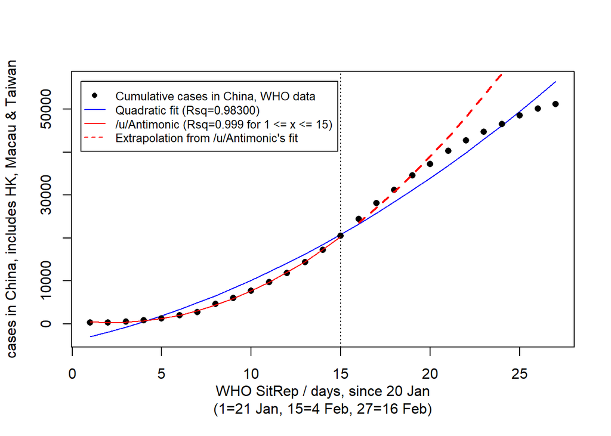

We note that the reported numbers follow the model almost exactly, up until WHO SitRep 15 (containing data as of 4 Feb 1000hrs CET/UTC+1). /u/Antimonic’s post was made on 5 Feb 0225hrs CET. On the subsequent days, the data began on diverge somewhat from that model’s predictions.

Our model still fits to the data fairly well (blue line; R<sup>2</sup>=0.983). As a quick-and-dirty check, we plotted the residuals of the original model and compared them against our model. We find that the residuals vary much more widely when a wider range of data is fed to a quadratic model. Furthermore, there is a remarkable sinusoidal pattern in the residuals of our model, suggesting that a quadratic function does not approximate the data well.

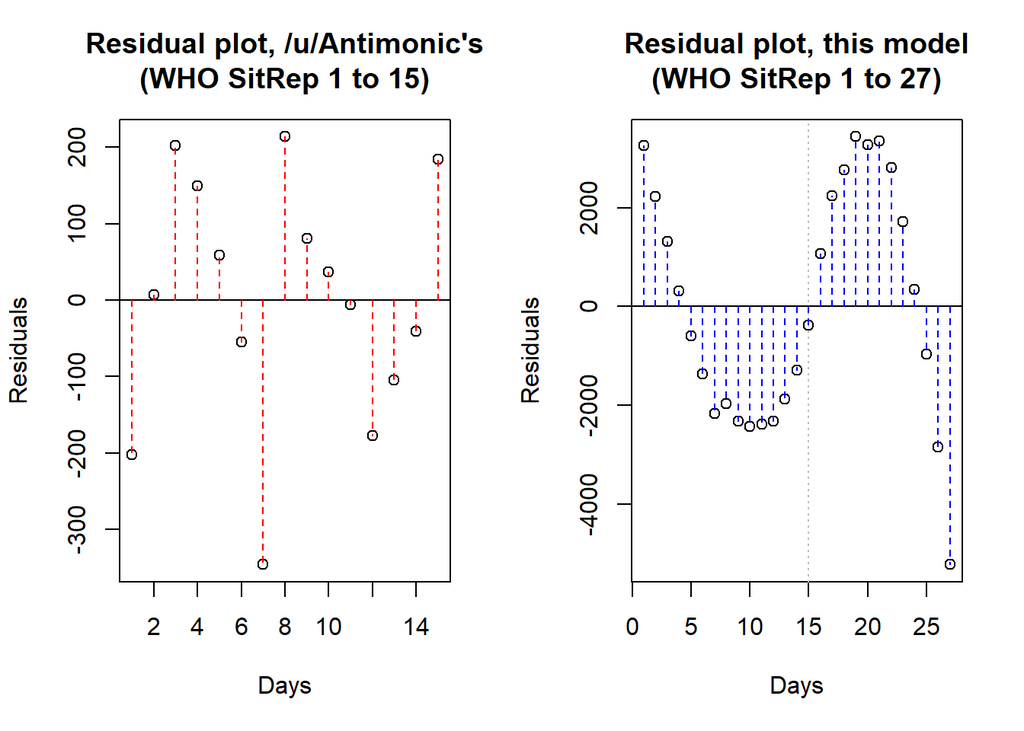

### Comparison with SARS (2003)

For the sake of comparison, we provide a quick visualization of the growth in cases by trying to fit a quadratic curve to case counts for the 2003 SARS outbreak, using a similar approach as above. We use data dated between 17 Mar and 17 May 2003 from a dataset of cumulative case counts scraped from the [WHO archives](https://www.who.int/csr/sars/country/en/).

```r
sarsDays <- 54
df.sars <- read.csv('sars-cases.csv', nrows=sarsDays, header=T)
df.sars$chinaTotal <- as.numeric(df.sars$sarCount) + as.numeric(df.sars$chinaCount)
str(df.sars)  # sarCount is for cases reported in Hong Kong, Taiwan and Macau
```

```
## 'data.frame':    54 obs. of  5 variables:
##  $ date      : Factor w/ 54 levels "1 April 2003",..: 16 19 21 24 26 28 31 33 35 36 ...
##  $ totalCount: int  167 219 264 306 350 386 456 487 1323 1408 ...
##  $ sarCount  : int  95 123 150 173 203 222 260 286 316 367 ...
##  $ chinaCount: int  0 0 0 0 0 0 0 0 792 806 ...
##  $ chinaTotal: num  95 123 150 173 203 ...
```

```r
df.sars$days <- c(1:sarsDays)
df.sars$days2 <- c(1:sarsDays) ^ 2

m.sars <- lm(chinaTotal ~ days2 + days, data=df.sars)
```

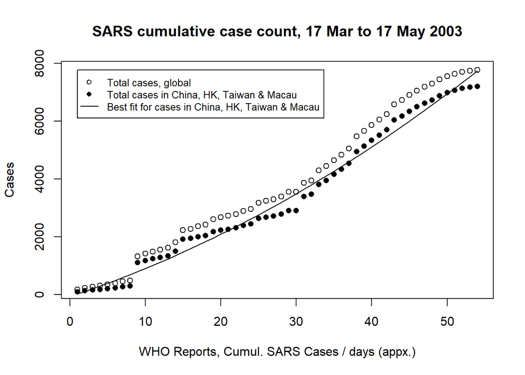